# Stat 425 Final Project

Minji Song

# Explantory Data Analysis

```r
library(ggplot2)
library(cowplot)
library(ggcorrplot)
library(dplyr)
data = read.csv("C:/Users/sec/Desktop/HW UIUC/SP 20/STAT 425/stat425_fpdata.csv")

data$is_canceled <- as.factor(ifelse(data$is_canceled==1, 'Yes', 'No'))


data$meal = recode(data$meal, SC = 'no meal', Undefined = 'no meal')

data = data[, -1]
set.seed(2)
trn_idx = sample(nrow(data), size = 0.8 * nrow(data))
trn = data[trn_idx, ]
tst = data[trn_idx, ]
```

I changed some values of the is_canceled variable and meal variable. is_canceled variable is a categorical variable with 0 and 1, so I changed it to 0 to No and 1 to Yes to identify values easily. For meal variables, SC and Undefined have the same meaning but they are different values, thus I combined both values to name it as no meal.

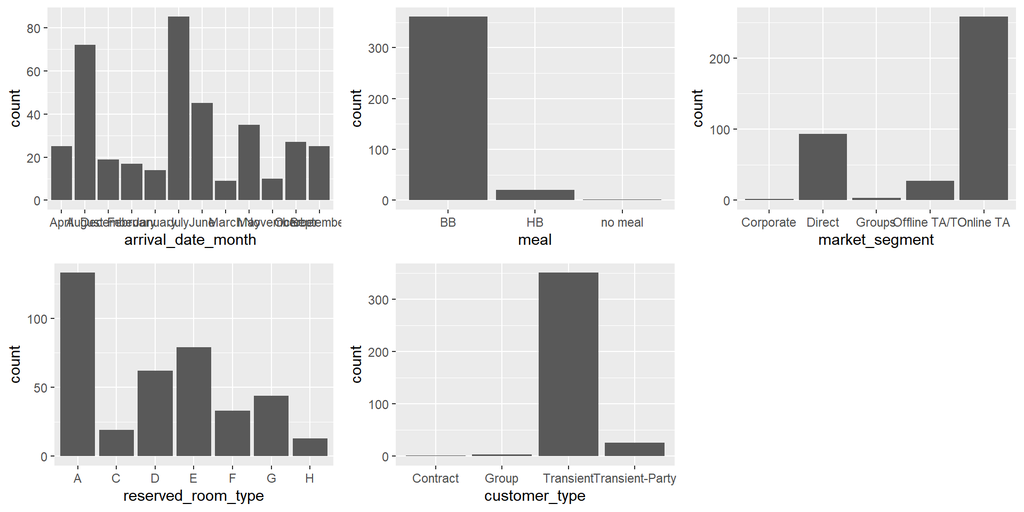

```r
plot_grid( ggplot(trn, aes(x=arrival_date_month))+ geom_bar() , ggplot(trn, aes(x=meal))+ geom_bar() , ggplot(trn, aes(x=market_segment))+ geom_bar() , ggplot(trn, aes(x=reserved_room_type, ))+ geom_bar(), ggplot(trn, aes(x=customer_type, ))+ geom_bar())
```

For categorical variables, I performed Explanatory Data Analysis by plotting each categorical variable to see the relationship between adr and other variables. These bar plots show the proportion of each variable. Meal and reserved room types are right-skewed and the market segment is left-skewed. There is no variable that has a perfect normal graph.

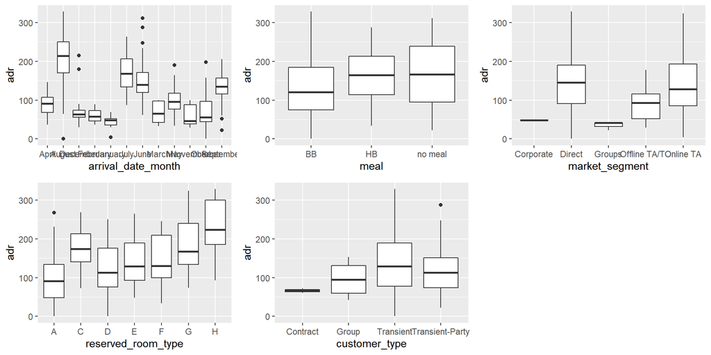

```r
plot_grid(ggplot(trn,aes(x=arrival_date_month, y=adr))+ geom_boxplot(), ggplot(trn,aes(x=meal, y=adr))+ geom_boxplot(), ggplot(trn,aes(x=market_segment, y=adr))+ geom_boxplot(), ggplot(trn,aes(x=reserved_room_type, y=adr))+ geom_boxplot(), ggplot(trn,aes(x=customer_type, y=adr))+ geom_boxplot())
```

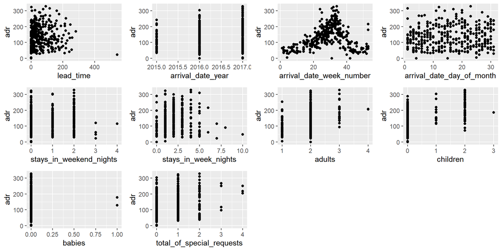

```r
plot_grid(ggplot(trn,aes(x=lead_time, y=adr))+ geom_point(),
ggplot(trn,aes(x=arrival_date_year, y=adr))+ geom_point(),
ggplot(trn,aes(x=arrival_date_week_number, y=adr))+ geom_point(),
ggplot(trn,aes(x=arrival_date_day_of_month, y=adr))+ geom_point(),
ggplot(trn,aes(x=stays_in_weekend_nights, y=adr))+ geom_point(),
ggplot(trn,aes(x=stays_in_week_nights, y=adr))+ geom_point(),
ggplot(trn,aes(x=adults, y=adr))+ geom_point(),
ggplot(trn,aes(x=children, y=adr))+ geom_point(),
ggplot(trn,aes(x=babies, y=adr))+ geom_point(),
ggplot(trn,aes(x=total_of_special_requests, y=adr))+ geom_point())
```

It seems lead time and arrival date week numer have trend in each plot so we might think the relationship between the two.

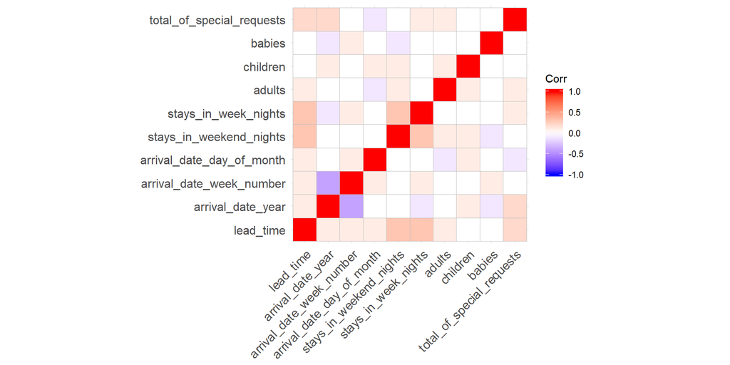

```r
correl = round(cor(trn[,c("lead_time", "arrival_date_year", "arrival_date_week_number", "arrival_date_day_of_month", "stays_in_weekend_nights", "stays_in_week_nights", "adults", "children", "babies", "total_of_special_requests")]),1)

ggcorrplot(correl)
```

we see that arrival date week number and arrival date year tend to have a negative correlation more than other variables.

```r
m = lm(adr~. , trn)
```

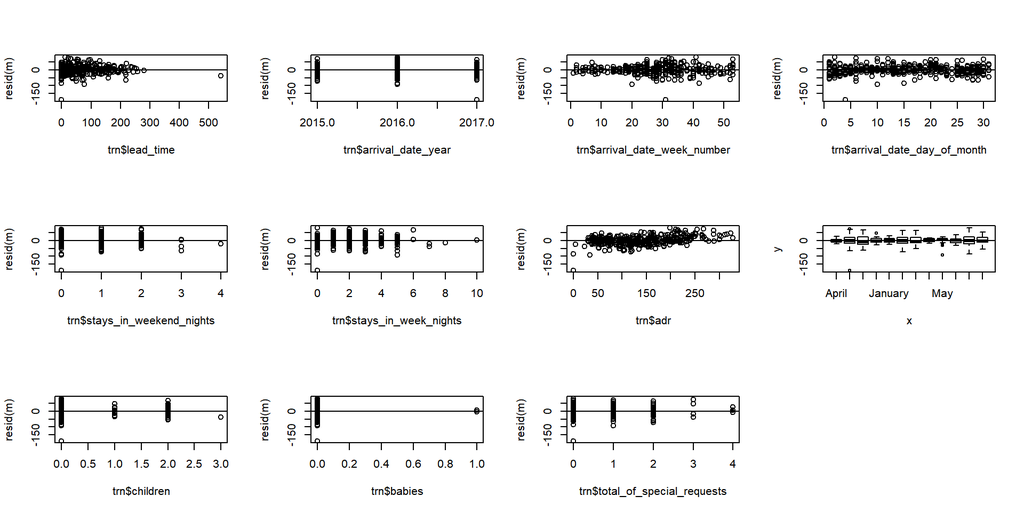

```r
par(mfrow=c(3,4))

plot(trn$lead_time ,resid(m))
abline(0,0)
plot(trn$arrival_date_year ,resid(m))
abline(0,0)
plot(trn$arrival_date_week_number ,resid(m))
abline(0,0)
plot(trn$arrival_date_day_of_month,resid(m))
abline(0,0)
plot(trn$stays_in_weekend_nights,resid(m))
abline(0,0)
plot(trn$stays_in_week_nights,resid(m))
abline(0,0)
plot(trn$adr,resid(m))
abline(0,0)
plot(trn$arrival_date_month ,resid(m))
abline(0,0)
plot(trn$children ,resid(m))
abline(0,0)
plot(trn$babies ,resid(m))
abline(0,0)
plot(trn$total_of_special_requests ,resid(m))
abline(0,0)
```

All plots are well distributed and there is no clear trend. Even though lead time plot looks like to be a heteroscedasticity a bit in a little plot, it is distributed well enough. From the residual plots, none of the numerical variables support the nonlinear trend.

# Linear Regression

```r
m = lm(adr~. +lead_time*arrival_date_week_number,trn)
summary(m)
```

```
##
## Call:
## lm(formula = adr ~ . + lead_time * arrival_date_week_number,
##     data = trn)
##
## Residuals:
##     Min      1Q  Median      3Q     Max
## -190.04  -14.98   -0.91   14.74   79.58
##
## Coefficients:
##                                      Estimate Std. Error t value Pr(>|t|)
## (Intercept)                        -4.508e+04  6.685e+03  -6.742 6.59e-11 ***
## is_canceledYes                      1.691e+01  4.540e+00   3.725 0.000228 ***
## lead_time                          -2.042e-02  7.980e-02  -0.256 0.798136
## arrival_date_year                   2.234e+01  3.300e+00   6.769 5.60e-11 ***
## arrival_date_monthAugust            8.902e+01  7.010e+01   1.270 0.205008
## arrival_date_monthDecember         -5.809e+01  1.412e+02  -0.411 0.681046
## arrival_date_monthFebruary         -1.789e+01  3.589e+01  -0.498 0.618549
## arrival_date_monthJanuary          -3.416e+00  5.341e+01  -0.064 0.949043
## arrival_date_monthJuly              6.395e+01  5.246e+01   1.219 0.223629
## arrival_date_monthJune              3.771e+01  3.575e+01   1.055 0.292212
## arrival_date_monthMarch            -1.844e+01  2.178e+01  -0.847 0.397729
## arrival_date_monthMay              -1.841e+00  1.897e+01  -0.097 0.922748
## arrival_date_monthNovember         -5.433e+01  1.236e+02  -0.440 0.660473
## arrival_date_monthOctober          -3.343e+01  1.062e+02  -0.315 0.753034
## arrival_date_monthSeptember         3.147e+01  8.830e+01   0.356 0.721747
## arrival_date_week_number            1.980e+00  4.055e+00   0.488 0.625596
## arrival_date_day_of_month           2.021e-01  6.072e-01   0.333 0.739484
## stays_in_weekend_nights             8.356e-01  2.071e+00   0.403 0.686859
## stays_in_week_nights                2.667e+00  1.245e+00   2.142 0.032913 *
## adults                              1.714e+01  4.016e+00   4.267 2.57e-05 ***
## children                            1.466e+01  3.426e+00   4.279 2.44e-05 ***
## babies                             -3.037e+01  2.160e+01  -1.406 0.160647
## mealHB                              2.457e+01  7.410e+00   3.315 0.001013 **
## mealno meal                         4.663e+01  2.481e+01   1.879 0.061052 .
## market_segmentDirect                2.316e+01  2.353e+01   0.984 0.325674
## market_segmentGroups               -1.500e+01  2.928e+01  -0.512 0.608763
## market_segmentOffline TA/TO        -1.225e+00  2.337e+01  -0.052 0.958231
## market_segmentOnline TA             1.470e+01  2.329e+01   0.631 0.528179
## reserved_room_typeC                 2.559e+01  8.523e+00   3.002 0.002876 **
## reserved_room_typeD                 1.734e+01  4.584e+00   3.782 0.000184 ***
## reserved_room_typeE                 3.683e+01  4.493e+00   8.196 4.97e-15 ***
## reserved_room_typeF                 4.863e+01  6.202e+00   7.841 5.65e-14 ***
## reserved_room_typeG                 5.592e+01  6.545e+00   8.545 4.24e-16 ***
## reserved_room_typeH                 6.380e+01  9.802e+00   6.509 2.67e-10 ***
## customer_typeGroup                 -1.602e+01  2.713e+01  -0.591 0.555216
## customer_typeTransient              4.838e+00  2.295e+01   0.211 0.833188
## customer_typeTransient-Party        1.965e+01  2.367e+01   0.830 0.407006
## total_of_special_requests           4.801e+00  2.183e+00   2.199 0.028530 *
## lead_time:arrival_date_week_number -5.599e-03  2.619e-03  -2.138 0.033197 *
## ---
## Signif. codes:  0 '***' 0.001 '**' 0.01 '*' 0.05 '.' 0.1 ' ' 1
##
## Residual standard error: 28.68 on 344 degrees of freedom
## Multiple R-squared:  0.8472, Adjusted R-squared:  0.8304
## F-statistic: 50.21 on 38 and 344 DF,  p-value: < 2.2e-16
```

I performed linear regression using all variables and interaction terms with lead time and arrival date week numbers. In a summary, the p-value of interaction term is lower than 0.05, so we keep this significant variable in the model.

```r
new_mod = step(m, direction="both")
```

```
## Start:  AIC=2607.74
## adr ~ is_canceled + lead_time + arrival_date_year + arrival_date_month +
##     arrival_date_week_number + arrival_date_day_of_month + stays_in_weekend_nights +
##     stays_in_week_nights + adults + children + babies + meal +
##     market_segment + reserved_room_type + customer_type + total_of_special_requests +
##     lead_time * arrival_date_week_number
##
##                                      Df Sum of Sq    RSS    AIC
## - arrival_date_day_of_month           1        91 283063 2605.9
## - stays_in_weekend_nights             1       134 283106 2605.9
## <none>                                            282972 2607.7
## - babies                              1      1626 284598 2607.9
## - customer_type                       3      5088 288060 2608.6
## - lead_time:arrival_date_week_number  1      3761 286733 2610.8
## - stays_in_week_nights                1      3773 286746 2610.8
## - total_of_special_requests           1      3978 286950 2611.1
## - market_segment                      4     10612 293585 2613.8
## - meal                                2     11407 294379 2618.9
## - is_canceled                         1     11415 294387 2620.9
## - adults                              1     14974 297946 2625.5
## - children                            1     15061 298033 2625.6
## - arrival_date_year                   1     37694 320666 2653.6
## - reserved_room_type                  6    121770 404742 2732.8
## - arrival_date_month                 11    688128 971100 3058.0
##
## Step:  AIC=2605.86
## adr ~ is_canceled + lead_time + arrival_date_year + arrival_date_month +
##     arrival_date_week_number + stays_in_weekend_nights + stays_in_week_nights +
##     adults + children + babies + meal + market_segment + reserved_room_type +
##     customer_type + total_of_special_requests + lead_time:arrival_date_week_number
##
##                                      Df Sum of Sq    RSS    AIC
## - stays_in_weekend_nights             1       107 283171 2604.0
## <none>                                            283063 2605.9
## - babies                              1      1660 284723 2606.1
## - customer_type                       3      5042 288106 2606.6
## + arrival_date_day_of_month           1        91 282972 2607.7
## - lead_time:arrival_date_week_number  1      3940 287003 2609.2
## - stays_in_week_nights                1      4011 287074 2609.2
## - total_of_special_requests           1      4095 287158 2609.4
```

[output cut: 17 more lines]

```
## - babies                              1      1719 284890 2604.3
## - customer_type                       3      4938 288109 2604.6
## + stays_in_weekend_nights             1       107 283063 2605.9
## + arrival_date_day_of_month           1        65 283106 2605.9
## - lead_time:arrival_date_week_number  1      3903 287074 2607.2
## - total_of_special_requests           1      4036 287207 2607.4
## - stays_in_week_nights                1      4448 287618 2608.0
## - market_segment                      4     10551 293721 2610.0
## - meal                                2     11346 294516 2615.1
## - is_canceled                         1     11416 294586 2617.2
## - adults                              1     15278 298448 2622.1
## - children                            1     15837 299008 2622.8
## - arrival_date_year                   1     59403 342574 2674.9
## - reserved_room_type                  6    122558 405729 2729.8
## - arrival_date_month                 11    689087 972257 3054.5
```

```r
summary(new_mod)
```

```
##
## Call:
## lm(formula = adr ~ is_canceled + lead_time + arrival_date_year +
##     arrival_date_month + arrival_date_week_number + stays_in_week_nights +
##     adults + children + babies + meal + market_segment + reserved_room_type +
##     customer_type + total_of_special_requests + lead_time:arrival_date_week_number,
##     data = trn)
##
## Residuals:
##      Min       1Q   Median       3Q      Max
## -190.055  -14.856   -0.897   14.997   79.381
##
## Coefficients:
##                                      Estimate Std. Error t value Pr(>|t|)
## (Intercept)                        -4.620e+04  5.419e+03  -8.526 4.78e-16 ***
## is_canceledYes                      1.691e+01  4.527e+00   3.735 0.000220 ***
## lead_time                          -1.731e-02  7.934e-02  -0.218 0.827428
## arrival_date_year                   2.288e+01  2.686e+00   8.520 5.00e-16 ***
## arrival_date_monthAugust            6.672e+01  2.139e+01   3.119 0.001968 **
## arrival_date_monthDecember         -1.035e+02  4.160e+01  -2.488 0.013327 *
## arrival_date_monthFebruary         -6.267e+00  1.343e+01  -0.467 0.641046
## arrival_date_monthJanuary           1.362e+01  1.803e+01   0.756 0.450416
## arrival_date_monthJuly              4.726e+01  1.622e+01   2.914 0.003797 **
## arrival_date_monthJune              2.654e+01  1.210e+01   2.193 0.028986 *
## arrival_date_monthMarch            -1.205e+01  1.302e+01  -0.925 0.355363
## arrival_date_monthMay              -6.976e+00  9.356e+00  -0.746 0.456390
## arrival_date_monthNovember         -9.390e+01  3.621e+01  -2.593 0.009919 **
## arrival_date_monthOctober          -6.771e+01  3.133e+01  -2.161 0.031377 *
## arrival_date_monthSeptember         3.017e+00  2.650e+01   0.114 0.909397
## arrival_date_week_number            3.287e+00  1.164e+00   2.824 0.005016 **
## stays_in_week_nights                2.812e+00  1.206e+00   2.331 0.020318 *
## adults                              1.723e+01  3.989e+00   4.321 2.04e-05 ***
## children                            1.488e+01  3.383e+00   4.399 1.45e-05 ***
## babies                             -3.115e+01  2.149e+01  -1.449 0.148147
## mealHB                              2.425e+01  7.352e+00   3.298 0.001074 **
## mealno meal                         4.768e+01  2.466e+01   1.934 0.053955 .
## market_segmentDirect                2.232e+01  2.334e+01   0.956 0.339599
## market_segmentGroups               -1.591e+01  2.911e+01  -0.546 0.585082
## market_segmentOffline TA/TO        -1.902e+00  2.316e+01  -0.082 0.934606
## market_segmentOnline TA             1.385e+01  2.309e+01   0.600 0.548916
## reserved_room_typeC                 2.526e+01  8.476e+00   2.981 0.003079 **
## reserved_room_typeD                 1.745e+01  4.566e+00   3.821 0.000157 ***
## reserved_room_typeE                 3.701e+01  4.465e+00   8.290 2.54e-15 ***
## reserved_room_typeF                 4.848e+01  6.177e+00   7.849 5.29e-14 ***
## reserved_room_typeG                 5.600e+01  6.518e+00   8.591 2.99e-16 ***
## reserved_room_typeH                 6.373e+01  9.745e+00   6.539 2.22e-10 ***
## customer_typeGroup                 -1.745e+01  2.688e+01  -0.649 0.516662
## customer_typeTransient              3.476e+00  2.271e+01   0.153 0.878451
## customer_typeTransient-Party        1.782e+01  2.328e+01   0.766 0.444344
## total_of_special_requests           4.814e+00  2.168e+00   2.221 0.027016 *
## lead_time:arrival_date_week_number -5.667e-03  2.595e-03  -2.184 0.029643 *
## ---
## Signif. codes:  0 '***' 0.001 '**' 0.01 '*' 0.05 '.' 0.1 ' ' 1
##
## Residual standard error: 28.61 on 346 degrees of freedom
## Multiple R-squared:  0.8471, Adjusted R-squared:  0.8312
## F-statistic: 53.26 on 36 and 346 DF,  p-value: < 2.2e-16
```

```r
library(faraway)
vif(new_mod)
```

```
##                     is_canceledYes                          lead_time
##                           1.301232                          13.944653
##                  arrival_date_year           arrival_date_monthAugust
##                           1.533816                          32.694813
##         arrival_date_monthDecember         arrival_date_monthFebruary
##                          38.192252                           3.580339
##          arrival_date_monthJanuary             arrival_date_monthJuly
##                           5.355276                          21.251669
##             arrival_date_monthJune            arrival_date_monthMarch
##                           7.110077                           1.820790
##              arrival_date_monthMay         arrival_date_monthNovember
##                           3.401439                          15.604355
##          arrival_date_monthOctober        arrival_date_monthSeptember
##                          30.100962                          20.045836
##           arrival_date_week_number               stays_in_week_nights
##                          81.384677                           1.405875
##                             adults                           children
##                           1.216240                           2.304569
##                             babies                             mealHB
##                           1.122733                           1.251979
##                        mealno meal               market_segmentDirect
##                           1.477858                          46.868723
##               market_segmentGroups        market_segmentOffline TA/TO
##                           3.081207                          16.449344
##            market_segmentOnline TA                reserved_room_typeC
##                          54.858598                           1.585010
##                reserved_room_typeD                reserved_room_typeE
##                           1.323983                           1.527565
##                reserved_room_typeF                reserved_room_typeG
##                           1.405789                           2.021917
##                reserved_room_typeH                 customer_typeGroup
##                           1.457283                           3.495078
##             customer_typeTransient       customer_typeTransient-Party
##                          18.484308                          16.043321
##          total_of_special_requests lead_time:arrival_date_week_number
##                           1.409475                          15.867242
```

```r
new_mod = lm(formula = adr ~ is_canceled + lead_time + arrival_date_year + arrival_date_month + arrival_date_week_number + stays_in_week_nights +  adults + children + babies + meal + market_segment + reserved_room_type + customer_type + total_of_special_requests + lead_time:arrival_date_week_number, data = trn)
```

Before we confirm the final model, I performed the VIF test to see if there is any multicollinearity with this model. It seems like there is multicollinearity in this model because some values have high VIF values. The highest VIF is arrival date week number with 81.3846, there are few more variables that have over 10 VIFs. However, those variables that have high VIF values can be ignored since those are either categorical variables with more than two levels or part of interaction terms. Other than those variables, all other variables look good.

```r
test = trn[c(1,1,1),]
test$arrival_date_week_number= c(min(trn$arrival_date_week_number), median(trn$arrival_date_week_number), max(trn$arrival_date_week_number))
test
```

```
##       is_canceled lead_time arrival_date_year arrival_date_month
## 341            No        65              2017           February
## 341.1          No        65              2017           February
## 341.2          No        65              2017           February
##       arrival_date_week_number arrival_date_day_of_month
## 341                          1                        16
## 341.1                       29                        16
## 341.2                       53                        16
##       stays_in_weekend_nights stays_in_week_nights adults children babies meal
## 341                         2                    3      2        0      0   BB
## 341.1                       2                    3      2        0      0   BB
## 341.2                       2                    3      2        0      0   BB
##       market_segment reserved_room_type customer_type adr
## 341        Online TA                  A     Transient  48
## 341.1      Online TA                  A     Transient  48
## 341.2      Online TA                  A     Transient  48
##       total_of_special_requests
## 341                           1
## 341.1                         1
## 341.2                         1
```

```r
predict(new_mod, test)
```

```
##       341     341.1     341.2
##  21.73755 103.46875 173.52406
```

A large number of arrival date week number has a higher average daily rate than a small number of arrival date week number. When the arrival date week number is 1, 29 and 53, the predicted adr are 21.74, 103.47, and 173.52.

```r
test = trn[c(1,1,1),]
test$lead_time= c(min(trn$lead_time), median(trn$lead_time), max(trn$lead_time))
test
```

```
##       is_canceled lead_time arrival_date_year arrival_date_month
## 341            No         0              2017           February
## 341.1          No        36              2017           February
## 341.2          No       542              2017           February
##       arrival_date_week_number arrival_date_day_of_month
## 341                          7                        16
## 341.1                        7                        16
## 341.2                        7                        16
##       stays_in_weekend_nights stays_in_week_nights adults children babies meal
## 341                         2                    3      2        0      0   BB
## 341.1                       2                    3      2        0      0   BB
## 341.2                       2                    3      2        0      0   BB
##       market_segment reserved_room_type customer_type adr
## 341        Online TA                  A     Transient  48
## 341.1      Online TA                  A     Transient  48
## 341.2      Online TA                  A     Transient  48
##       total_of_special_requests
## 341                           1
## 341.1                         1
## 341.2                         1
```

```r
predict(new_mod, test)
```

```
##      341    341.1    341.2
## 42.95474 40.90365 12.07437
```

```r
test = trn[c(1,1,1),]
test$arrival_date_year  = c(min(trn$arrival_date_year  ), median(trn$arrival_date_year  ), max(trn$arrival_date_year  ))
test
```

```
##       is_canceled lead_time arrival_date_year arrival_date_month
## 341            No        65              2015           February
## 341.1          No        65              2016           February
## 341.2          No        65              2017           February
##       arrival_date_week_number arrival_date_day_of_month
## 341                          7                        16
## 341.1                        7                        16
## 341.2                        7                        16
##       stays_in_weekend_nights stays_in_week_nights adults children babies meal
## 341                         2                    3      2        0      0   BB
## 341.1                       2                    3      2        0      0   BB
## 341.2                       2                    3      2        0      0   BB
##       market_segment reserved_room_type customer_type adr
## 341        Online TA                  A     Transient  48
## 341.1      Online TA                  A     Transient  48
## 341.2      Online TA                  A     Transient  48
##       total_of_special_requests
## 341                           1
## 341.1                         1
## 341.2                         1
```

```r
predict(new_mod, test)
```

```
##       341     341.1     341.2
## -6.517773 16.366801 39.251375
```

This data set is for between 2015 and 2017. In 2015, the average daily rate is much lower than in 2017. In 2017, the rate has increased by about 45% compared to 2015 and it was -6.5 in 2015.

```r
test = trn[c(1,1,1),]
test$stays_in_week_nights  = c(min(trn$stays_in_week_nights  ), median(trn$stays_in_week_nights  ), max(trn$stays_in_week_nights  ))
test
```

```
##       is_canceled lead_time arrival_date_year arrival_date_month
## 341            No        65              2017           February
## 341.1          No        65              2017           February
## 341.2          No        65              2017           February
##       arrival_date_week_number arrival_date_day_of_month
## 341                          7                        16
## 341.1                        7                        16
## 341.2                        7                        16
##       stays_in_weekend_nights stays_in_week_nights adults children babies meal
## 341                         2                    0      2        0      0   BB
## 341.1                       2                    2      2        0      0   BB
## 341.2                       2                   10      2        0      0   BB
##       market_segment reserved_room_type customer_type adr
## 341        Online TA                  A     Transient  48
## 341.1      Online TA                  A     Transient  48
## 341.2      Online TA                  A     Transient  48
##       total_of_special_requests
## 341                           1
## 341.1                         1
## 341.2                         1
```

```r
predict(new_mod, test)
```

```
##      341    341.1    341.2
## 30.81557 36.43944 58.93493
```

The more nights staying in a week increases the average daily rate. The difference between 0 nights to 10 nights is 28.1% .

```r
test = trn[c(1,1,1),]
test$adults  = c(min(trn$adults  ), median(trn$adults  ), max(trn$adults  ))
test
```

```
##       is_canceled lead_time arrival_date_year arrival_date_month
## 341            No        65              2017           February
## 341.1          No        65              2017           February
## 341.2          No        65              2017           February
##       arrival_date_week_number arrival_date_day_of_month
## 341                          7                        16
## 341.1                        7                        16
## 341.2                        7                        16
##       stays_in_weekend_nights stays_in_week_nights adults children babies meal
## 341                         2                    3      1        0      0   BB
## 341.1                       2                    3      2        0      0   BB
## 341.2                       2                    3      4        0      0   BB
##       market_segment reserved_room_type customer_type adr
## 341        Online TA                  A     Transient  48
## 341.1      Online TA                  A     Transient  48
## 341.2      Online TA                  A     Transient  48
##       total_of_special_requests
## 341                           1
## 341.1                         1
## 341.2                         1
```

```r
predict(new_mod, test)
```

```
##      341    341.1    341.2
## 22.01702 39.25137 73.72007
```

```r
test = trn[c(1,1,1),]
test$children  = c(min(trn$children  ), median(trn$children  ), max(trn$children  ))
test
```

```
##       is_canceled lead_time arrival_date_year arrival_date_month
## 341            No        65              2017           February
## 341.1          No        65              2017           February
## 341.2          No        65              2017           February
##       arrival_date_week_number arrival_date_day_of_month
## 341                          7                        16
## 341.1                        7                        16
## 341.2                        7                        16
##       stays_in_weekend_nights stays_in_week_nights adults children babies meal
## 341                         2                    3      2        0      0   BB
## 341.1                       2                    3      2        0      0   BB
## 341.2                       2                    3      2        3      0   BB
##       market_segment reserved_room_type customer_type adr
## 341        Online TA                  A     Transient  48
## 341.1      Online TA                  A     Transient  48
## 341.2      Online TA                  A     Transient  48
##       total_of_special_requests
## 341                           1
## 341.1                         1
## 341.2                         1
```

```r
predict(new_mod, test)
```

```
##      341    341.1    341.2
## 39.25137 39.25137 83.89169
```

More adults and children also increase the average daily rate.

```r
test = trn[c(1,1,1),]
test$total_of_special_requests = c(min(trn$total_of_special_requests), median(trn$total_of_special_requests), max(trn$total_of_special_requests))
test
```

```
##       is_canceled lead_time arrival_date_year arrival_date_month
## 341            No        65              2017           February
## 341.1          No        65              2017           February
## 341.2          No        65              2017           February
##       arrival_date_week_number arrival_date_day_of_month
## 341                          7                        16
## 341.1                        7                        16
## 341.2                        7                        16
##       stays_in_weekend_nights stays_in_week_nights adults children babies meal
## 341                         2                    3      2        0      0   BB
## 341.1                       2                    3      2        0      0   BB
## 341.2                       2                    3      2        0      0   BB
##       market_segment reserved_room_type customer_type adr
## 341        Online TA                  A     Transient  48
## 341.1      Online TA                  A     Transient  48
## 341.2      Online TA                  A     Transient  48
##       total_of_special_requests
## 341                           0
## 341.1                         1
## 341.2                         4
```

```r
predict(new_mod, test)
```

```
##      341    341.1    341.2
## 34.43697 39.25137 53.69459
```

# Regression Tree

```r
library(rpart)
rpmod = rpart(adr ~ is_canceled + lead_time + arrival_date_year + arrival_date_month + arrival_date_week_number + stays_in_week_nights +  adults + children + babies + meal + market_segment + reserved_room_type + customer_type + total_of_special_requests,cp=0.01, data = trn)
rpmod
```

```
## n= 383
##
## node), split, n, deviance, yval
##       * denotes terminal node
##
##  1) root 383 1852467.00 134.49170
##    2) arrival_date_month=April,December,February,January,March,May,November,October,September 181  310527.70  84.19547
##      4) reserved_room_type=A,D 94   85575.85  62.04979
##        8) arrival_date_month=December,February,January,March,November,October 57   19266.29  48.28842 *
##        9) arrival_date_month=April,May,September 37   38885.98  83.24973 *
##      5) reserved_room_type=C,E,F,G,H 87  129041.60 108.12300
##       10) arrival_date_month=April,December,February,January,March,November 42   44756.32  89.28357 *
##       11) arrival_date_month=May,October,September 45   55465.44 125.70640 *
##    3) arrival_date_month=August,July,June 202  673784.50 179.55920
##      6) reserved_room_type=A,D 101  240234.20 152.31550
##       12) arrival_date_week_number< 27.5 29   21127.08 122.20520 *
##       13) arrival_date_week_number>=27.5 72  182224.70 164.44330
##         26) total_of_special_requests< 1.5 61  134380.00 155.26590 *
##         27) total_of_special_requests>=1.5 11   14215.91 215.33640 *
##      7) reserved_room_type=C,E,F,G,H 101  283623.00 206.80280
##       14) arrival_date_week_number< 29.5 48  108385.30 179.26150
##         28) meal=BB 41   55722.41 167.91590 *
##         29) meal=HB,no meal 7   16473.43 245.71430 *
##       15) arrival_date_week_number>=29.5 53  105854.20 231.74580
##         30) reserved_room_type=C,E,F 37   39411.82 212.12700 *
##         31) reserved_room_type=G,H 16   19268.31 277.11440 *
```

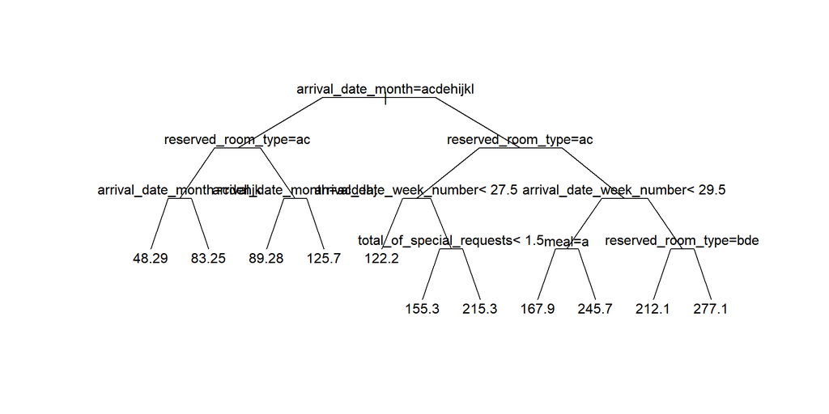

```r
plot(rpmod,compress=T,uniform=T,branch=0.4,margin=.10)
text(rpmod)
```

```r
printcp(rpmod)
```

```
##
## Regression tree:
## rpart(formula = adr ~ is_canceled + lead_time + arrival_date_year +
##     arrival_date_month + arrival_date_week_number + stays_in_week_nights +
##     adults + children + babies + meal + market_segment + reserved_room_type +
##     customer_type + total_of_special_requests, data = trn, cp = 0.01)
##
## Variables actually used in tree construction:
## [1] arrival_date_month        arrival_date_week_number
## [3] meal                      reserved_room_type
## [5] total_of_special_requests
##
## Root node error: 1852467/383 = 4836.7
##
## n= 383
##
##          CP nsplit rel error  xerror     xstd
## 1  0.468648      0   1.00000 1.00596 0.062974
## 2  0.080934      1   0.53135 0.57566 0.043383
## 3  0.051774      2   0.45042 0.53109 0.036354
## 4  0.037455      3   0.39864 0.49549 0.035560
## 5  0.025466      4   0.36119 0.43074 0.035600
## 6  0.019910      5   0.33572 0.42619 0.035552
## 7  0.019536      6   0.31581 0.42262 0.035522
## 8  0.018154      7   0.29628 0.41243 0.035487
## 9  0.015558      8   0.27812 0.40657 0.035933
## 10 0.014804      9   0.26257 0.40179 0.039373
## 11 0.010000     10   0.24776 0.38747 0.038920
```

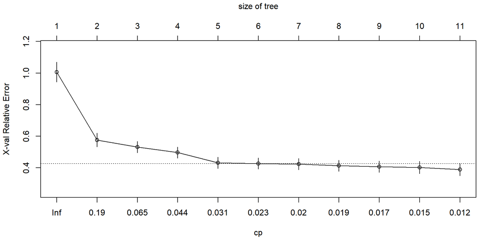

```r
plotcp(rpmod)
```

This regression split the model into several steps and the first node of the variable we split on is arrival date month with 181 observations. The second branch is also an arrival date month with 202 observations. It is telling that the most important variable in this regression is the arrival date month.

```r
rpmods = rpart(adr ~ is_canceled + lead_time + arrival_date_year + arrival_date_month + arrival_date_week_number + stays_in_week_nights +  adults + children + babies + meal + market_segment + reserved_room_type + customer_type + total_of_special_requests,
    cp=0.001, data = trn)

printcp(rpmods)
```

```
##
## Regression tree:
## rpart(formula = adr ~ is_canceled + lead_time + arrival_date_year +
##     arrival_date_month + arrival_date_week_number + stays_in_week_nights +
##     adults + children + babies + meal + market_segment + reserved_room_type +
##     customer_type + total_of_special_requests, data = trn, cp = 0.001)
##
## Variables actually used in tree construction:
##  [1] adults                    arrival_date_month
##  [3] arrival_date_week_number  arrival_date_year
##  [5] children                  lead_time
##  [7] market_segment            meal
##  [9] reserved_room_type        total_of_special_requests
##
## Root node error: 1852467/383 = 4836.7
##
## n= 383
##
##           CP nsplit rel error  xerror     xstd
## 1  0.4686479      0   1.00000 1.00218 0.062561
## 2  0.0809339      1   0.53135 0.55649 0.042265
## 3  0.0517744      2   0.45042 0.51285 0.037279
## 4  0.0374546      3   0.39864 0.48359 0.036853
## 5  0.0254655      4   0.36119 0.44158 0.035134
## 6  0.0199099      5   0.33572 0.43804 0.034193
## 7  0.0195358      6   0.31581 0.42923 0.034723
## 8  0.0181535      7   0.29628 0.41922 0.034290
## 9  0.0155575      8   0.27812 0.40433 0.034013
## 10 0.0148038      9   0.26257 0.37839 0.033289
## 11 0.0096474     10   0.24776 0.34935 0.030431
## 12 0.0085356     13   0.21882 0.33808 0.028171
## 13 0.0066706     14   0.21029 0.34112 0.028474
## 14 0.0058331     15   0.20361 0.32790 0.028353
## 15 0.0053710     16   0.19778 0.32138 0.027719
## 16 0.0047816     17   0.19241 0.31391 0.027523
## 17 0.0035575     19   0.18285 0.31140 0.026983
## 18 0.0033983     20   0.17929 0.30934 0.026991
## 19 0.0030461     21   0.17589 0.30600 0.026059
## 20 0.0028928     23   0.16980 0.30418 0.025887
## 21 0.0020060     24   0.16691 0.30366 0.026201
## 22 0.0018369     25   0.16490 0.30212 0.025980
## 23 0.0014659     26   0.16306 0.30227 0.025998
## 24 0.0011027     27   0.16160 0.30364 0.025946
## 25 0.0010000     28   0.16049 0.30186 0.025946
```

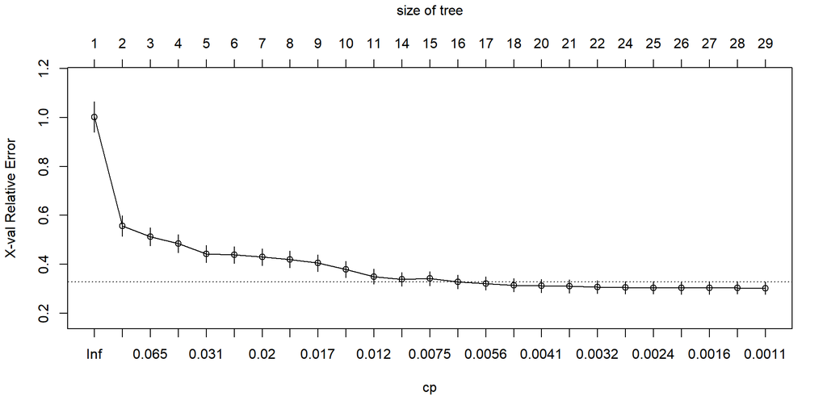

```r
plotcp(rpmods)
```

We can fit a bigger tree by pruning the tree using cp=0.001 instead of cp=0.01.

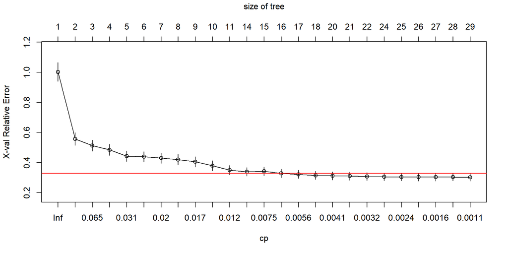

```r
tb=rpmods$cptable
id.min = which.min(tb[, 'xerror'])
err = tb[id.min,'xerror'] +tb[id.min, 'xstd']
plotcp(rpmods)
abline(h=err, col="red")
```

I chose smallest tree size with CV error within 1 standard error of the smallest CV error to determine the optimal tree size and the red line of the plot indicates the CV error within 1 standard error of the smallest CV error.

```r
id = min(which(tb[, 'xerror'] < err))
cp = (tb[id, 'CP'] + tb[id-1, 'CP'])/2
cp
```

```
## [1] 0.005602056
```

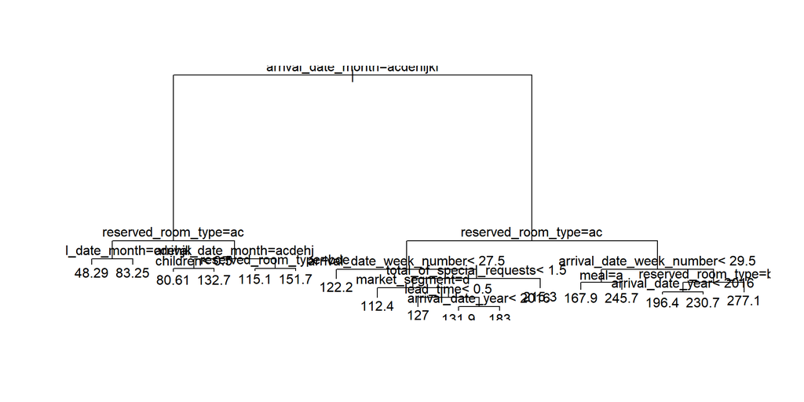

```r
cpp= prune.rpart(rpmods, cp)

plot(cpp)
text(cpp)
```

```r
library(rattle)
```

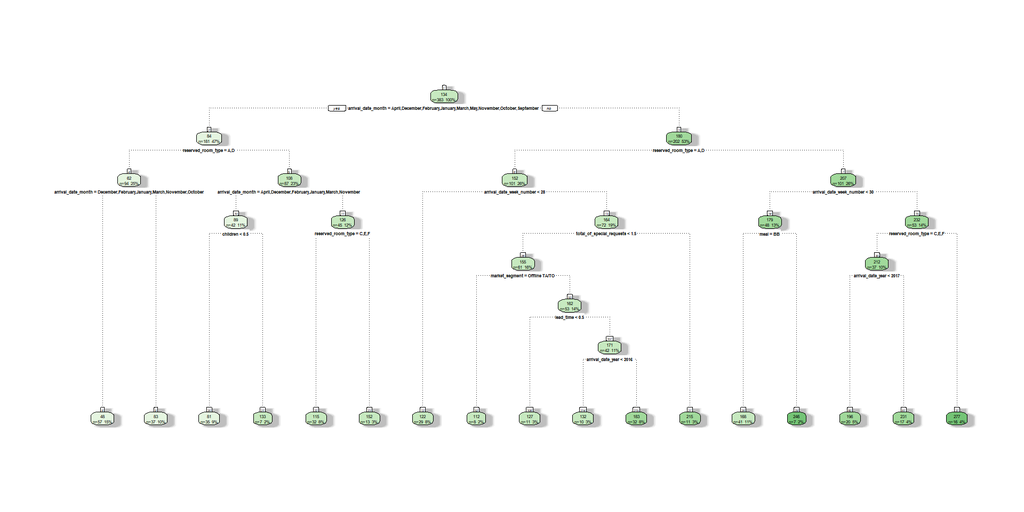

```r
library(rpart.plot)
library(RColorBrewer)

fancyRpartPlot(cpp, caption=NULL)
```

This is the final optimal regression tree size based on optimal cv error.

```r
library(randomForest)
rfm = randomForest(adr ~ is_canceled + reserved_room_type + market_segment + lead_time + arrival_date_year + arrival_date_week_number + stays_in_week_nights + adults + children + total_of_special_requests, trn)

p = predict(rfm, trn)

#training error
sum((trn$adr - p)^2)
```

```
## [1] 101966.9
```

```r
#test(CV) error
sum((trn$adr - rfm$predicted)^2)
```

```
## [1] 381974.4
```

Using the same predictors as linear regression in a tree model, I fitted the random forests to see how training error and cross-validation test errors are different. The training error is 101966.9 and the test error is 381974.4.